# Estimacion de Biomasa via Validacion Cruzada

Hector Chuquillanqui

10/6/2020

```r
library(tidyverse)
library(readxl)
library(stringr)
library(janitor)
library(plotly)
library(broom)
library(MuMIn) # To calculate AIC corrected for small samples (AICc)
library(caret) # To perform cross-validation

source("code/pairsPannelFunctions.R")
source("code/S01.helpers_functions.R")
```

## EXPLORE PERFORMANCE OF PREVIOUS ALLOMETRIC MMODELS

Calibrate and test models proposed by Oliveras etal. 2013 via cross validation with Biorestoration data

### 4.1 ITERATIVE PROCEDIMENT WITH CROSS-VALIDATION -

The following code calibrate a pre-defined set of equations by means of cross-validation method with caret::train, and repeat the proccess with a resampled 75% of Biorestoration data (train data), that changes at every iteration. After the calibration, the 25% left is used to assess model performance.

# –> NOTE 1: Proccess takes long time (around 20 minutes) for 100 iterations # and 6 equations with repeated cross-validation. Output object # was stored in a .RDS file (biorestoration_biomass_cross-val.rds) # which is called below in section 4.3.

### 4.3 EXPLORE COMPLETE CV OBJECT: 100 ITERATIONS WITH REPEATED CV —-

```r
biorest_cross_val_iter <- readRDS("data/biorestoration_biomass_cross-val.rds")
```

FUNCTION: Extract cv outputs and present in tibble (dataframe) format

```r
bind_cv_rows <-
  function(cv.output,
           output = c("trained", "predicted"),
           trained.out = c("results", "finalModel", "pred", "resample")
           ) {

  output <- match.arg(output)
  trained.out <- match.arg(trained.out)

  if(output == "predicted") fun.formula <- formula(~ .x[[output]])
  if(output == "trained")   fun.formula <- formula(~ .x[[output]][[trained.out]])

  cv.output %>%
    purrr::map(
      .,
      .f = function(equa_lvl) {
        tmp <- equa_lvl %>% purrr::map(., fun.formula)
        if("lm" %in% class(tmp[[1]])) {
          tibble(equation = names(tmp), models = tmp)
        } else {
          tmp %>% bind_rows(., .id = "equation") %>% as_tibble
        }
      }
    ) %>%
    bind_rows(., .id = "iteration")

}
```

4.3.1 TRAINED CROSS-VALIDATION RESULTS Based on 75% of original data

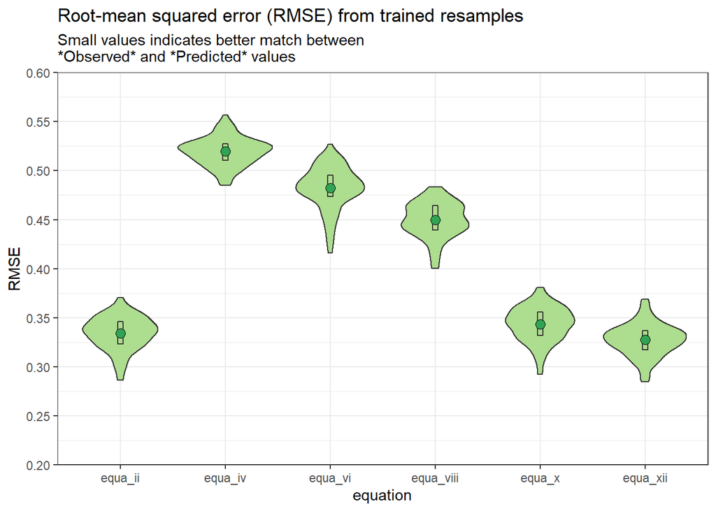

```r
cv_biorest_train_results <-
  biorest_cross_val_iter %>%
  bind_cv_rows(output = "trained", trained.out = "results")

cv_biorest_results_mean <-
  cv_biorest_train_results %>%
  group_by(equation) %>%
  summarise_if(is.numeric, mean)

cv_biorest_results_boxplot <-
  cv_biorest_train_results %>%
  group_by(equation) %>%
  summarise(ymin.whisker  = median(RMSE) - 1.5*IQR(RMSE),
            y25 = quantile(RMSE, 0.25),
            y50 = mean(RMSE),
            y75 = quantile(RMSE, 0.75),
            ymax.whisker = median(RMSE) + 1.5*IQR(RMSE)
            )

cv_biorest_train_results %>%
  ggplot(aes(x = equation, y = RMSE)) +
  geom_violin(fill = "#addd8e") +
  geom_boxplot(
    data = cv_biorest_results_boxplot %>% left_join(cv_biorest_results_mean),
    aes(ymin = y25, lower = y25,
        middle = y50,
        upper = y75, ymax = y75
        ),
    width = 0.05, fatten = NULL, fill = "NA",
    stat = "identity"
  ) +
  stat_summary(fun = mean, geom = "point", shape = 21, size = 3,
               fill = "#31a354") +
  scale_y_continuous(limits = c(0.2, 0.6),
                     breaks = seq(0.2, 0.6, 0.05),
                     expand = c(0,0)) +
  ggtitle(label = "Root-mean squared error (RMSE) from trained resamples",
          subtitle = paste0("Small values indicates better match between", "\n",
                            "*Observed* and *Predicted* values")) +
  theme_bw()
```

4.3.2 TESTED RESULTS FROM CROSS-VALIDATION

```r
# Based on 25% of original data
cv_biorest_test_predict <-
  biorest_cross_val_iter %>%
  bind_cv_rows(output = "predicted")

# Performance and coefficients for Observed ~ Predicted model
cv_biorest_test_perfor <-
  cv_biorest_test_predict %>%
  group_by(iteration, equation) %>%
  nest() %>%
  mutate(obs_pre_mods = purrr::map(data, ~ lm(AGB_obs ~ AGB_pre, data = .x)),
         mods_descrip = purrr::map(obs_pre_mods, ~ get_fit_descriptors(.x)),
         tidy_coeffic = purrr::map(obs_pre_mods, ~ broom::tidy(.x))
  )

# Mean of performance descriptors for each equation
cv_biorest_test_perfor_mean <-
  cv_biorest_test_perfor %>%
  unnest(mods_descrip) %>%
  group_by(equation) %>%
  summarise_if(is.numeric, mean)
```

Performance descriptors for each equation (means)

```r
cv_biorest_test_perfor_mean
```

```
## # A tibble: 6 x 7
##   equation  r.squared adj.r.squared sigma   AIC  AICc  RMSD
##   <chr>         <dbl>         <dbl> <dbl> <dbl> <dbl> <dbl>
## 1 equa_ii       0.702         0.672 0.330 10.8   13.8 0.314
## 2 equa_iv       0.238         0.161 0.529 22.5   25.5 0.504
## 3 equa_vi       0.357         0.292 0.488 20.3   23.3 0.466
## 4 equa_viii     0.445         0.390 0.450 18.4   21.4 0.429
## 5 equa_x        0.690         0.659 0.336 11.3   14.3 0.321
## 6 equa_xii      0.723         0.695 0.317  9.81  12.8 0.302
```

MODEL PERFORMANCES: RMSD

```r
### MODEL PERFORMANCE: RMSD
# Boxplot elements for RMSD (Root-mean square deviation) for each equation
cv_biorest_test_boxplot <-
  cv_biorest_test_perfor %>%
  unnest(mods_descrip) %>%
  group_by(equation) %>%
  summarise(ymin.whisker  = median(RMSD) - 1.5*IQR(RMSD),
            y25 = quantile(RMSD, 0.25),
            y50 = mean(RMSD),
            y75 = quantile(RMSD, 0.75),
            ymax.whisker = median(RMSD) + 1.5*IQR(RMSD)
  )

# Boostraping confidence interval (CI) for mean RMSD for each equation
cv_biorest_test_perfor_boot <-
  cv_biorest_test_perfor %>%
  unnest(mods_descrip) %>%
  group_by(equation) %>%
  summarise(mean = mean(get_mean_boot(RMSD)$t[,1]),
            ci_upp = get_ci_boot(get_mean_boot(RMSD))[5],
            ci_low = get_ci_boot(get_mean_boot(RMSD))[4]
  )

cv_biorest_test_perfor_boot
```

```
## # A tibble: 6 x 4
##   equation   mean ci_upp ci_low
##   <chr>     <dbl>  <dbl>  <dbl>
## 1 equa_ii   0.314  0.325  0.303
## 2 equa_iv   0.504  0.514  0.495
## 3 equa_vi   0.465  0.482  0.450
## 4 equa_viii 0.429  0.442  0.417
## 5 equa_x    0.321  0.332  0.310
## 6 equa_xii  0.302  0.312  0.290
```

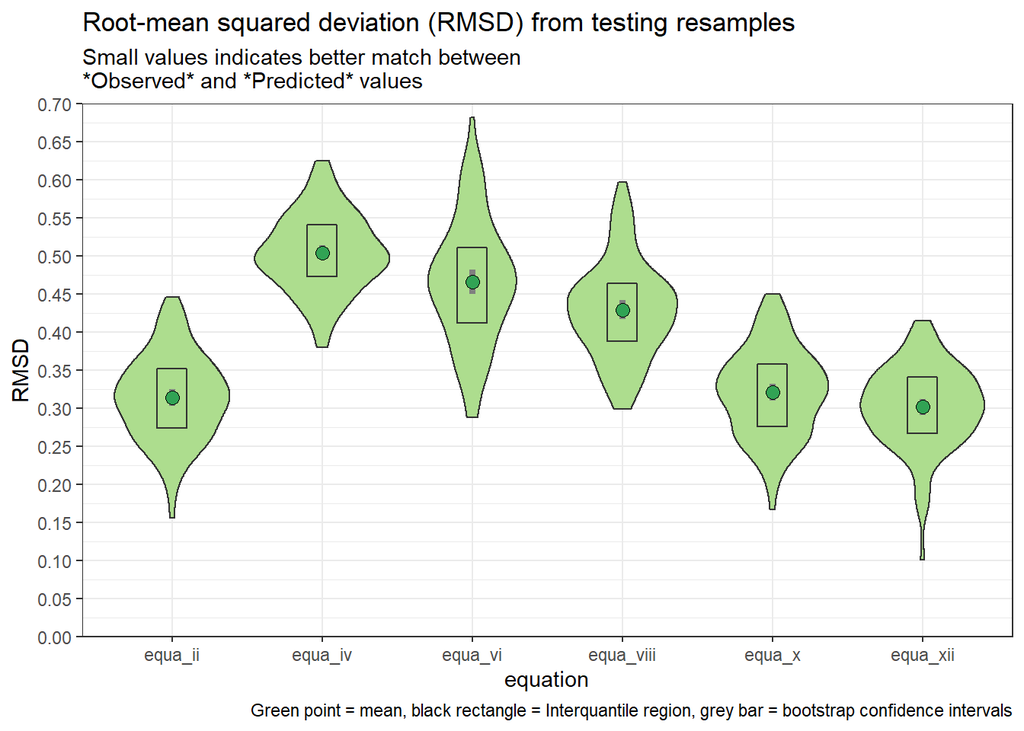

```r
# Plot RMSD for all equations used
cv_biorest_test_perfor %>%
  unnest(mods_descrip) %>%
  select(-data, -obs_pre_mods) %>%
  ggplot(aes(x = equation, y = RMSD)) +
  geom_violin(fill = "#addd8e") +
  geom_boxplot(
    data = cv_biorest_test_boxplot %>% left_join(cv_biorest_test_perfor_mean),
    aes(ymin = y25, lower = y25,
        middle = y50,
        upper = y75, ymax = y75
    ),
    width = 0.2, fatten = NULL, fill = "NA",
    stat = "identity"
  ) +
  geom_errorbar(
    data = cv_biorest_test_perfor_boot %>% left_join(cv_biorest_test_perfor_mean),
    aes(ymin = ci_low, ymax = ci_upp),
    color = "grey50", width = 0, size = 1.5
  ) +
  stat_summary(fun = mean, geom = "point", shape = 21, size = 3,
               fill = "#31a354") +
  scale_y_continuous(limits = c(0, 0.7),
                     breaks = seq(0, 0.7, 0.05),
                     expand = c(0,0)) +
  ggtitle(label = "Root-mean squared deviation (RMSD) from testing resamples",
          subtitle = paste0("Small values indicates better match between", "\n",
                            "*Observed* and *Predicted* values")
          ) +
  labs(caption = paste0("Green point = mean, ",
                        "black rectangle = Interquantile region, ",
                        "grey bar = bootstrap confidence intervals")
       ) +
  theme_bw()
```

### 4.4 TEST FOR DIFFERENCES IN PERFORMANCE AND COEFFICIENTS –

(Compare with plots produced in section 4.3.2)

Test for differences in RMDS between equations

```r
# Test for differences in RMSD between equations
test_rmsd_equation <-
  cv_biorest_test_perfor %>%
  unnest(mods_descrip) %>%
  ungroup() %>%
  mutate(equation = factor(equation)) %>%
  lm(RMSD ~ equation, data = .) %>%
  multcomp::glht(model = ., linfct = multcomp::mcp(equation = "Tukey")) %>%
  summary(., test = multcomp::adjusted("fdr"))

test_rmsd_equation %>% multcomp::cld(.)
```

```
##   equa_ii   equa_iv   equa_vi equa_viii    equa_x  equa_xii
##      "ab"       "e"       "d"       "c"       "b"       "a"
```

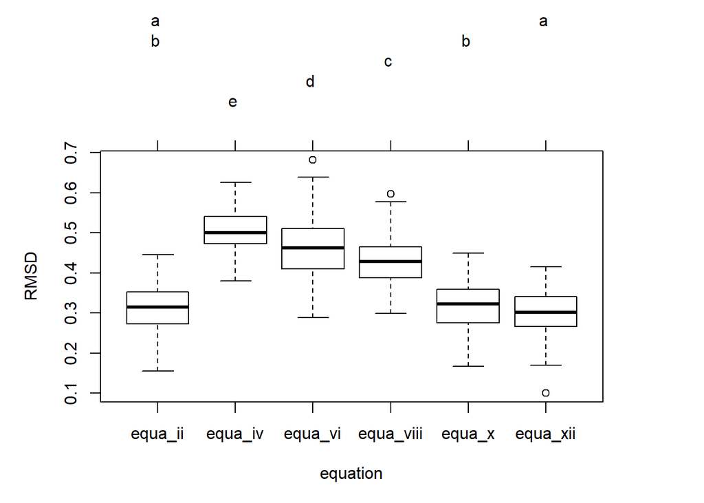

```r
old.par <- par(mai=c(1,1,1.5,1), no.readonly=TRUE)
test_rmsd_equation %>% multcomp::cld(.) %>% plot()
```

```r
par(old.par)
```

Test for differences in slope and intercept between equations

```r
# Test for differences in slope and intercept between equations
test_term_equation <-
  cv_biorest_test_perfor %>%
  unnest(tidy_coeffic) %>%
  ungroup() %>%
  mutate(equation = factor(equation)) %>%
  group_by(term) %>%
  nest() %>%
  mutate(model.coef = purrr::map(data, ~ lm(estimate ~ equation, data = .x))) %>%
  mutate(model.comp = purrr::map(model.coef,
                                 ~ multcomp::glht(
                                   model = .x,
                                   linfct = multcomp::mcp(equation = "Tukey")))
         ) %>%
  mutate(model.summ = purrr::map(model.comp,
                                ~ summary(.x,
                                          test = multcomp::adjusted("fdr"))))
```

– Differences between “intercept”

```r
test_term_equation$model.summ[[1]] %>% multcomp::cld()
```

```
##   equa_ii   equa_iv   equa_vi equa_viii    equa_x  equa_xii
##       "b"       "a"      "ab"       "b"       "b"       "b"
```

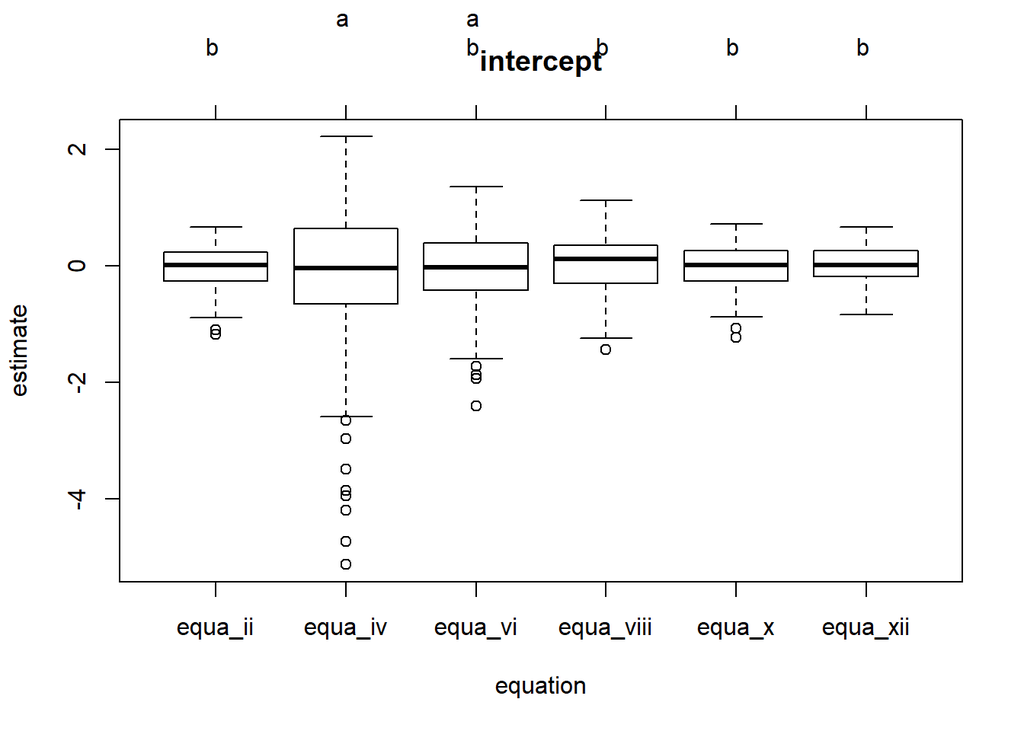

```r
plot(test_term_equation$model.summ[[1]] %>% multcomp::cld(), main = "intercept")
```

– Differences between “slope”

```r
test_term_equation$model.summ[[2]] %>% multcomp::cld()
```

```
##   equa_ii   equa_iv   equa_vi equa_viii    equa_x  equa_xii
##       "a"       "b"      "ab"       "a"       "a"       "a"
```

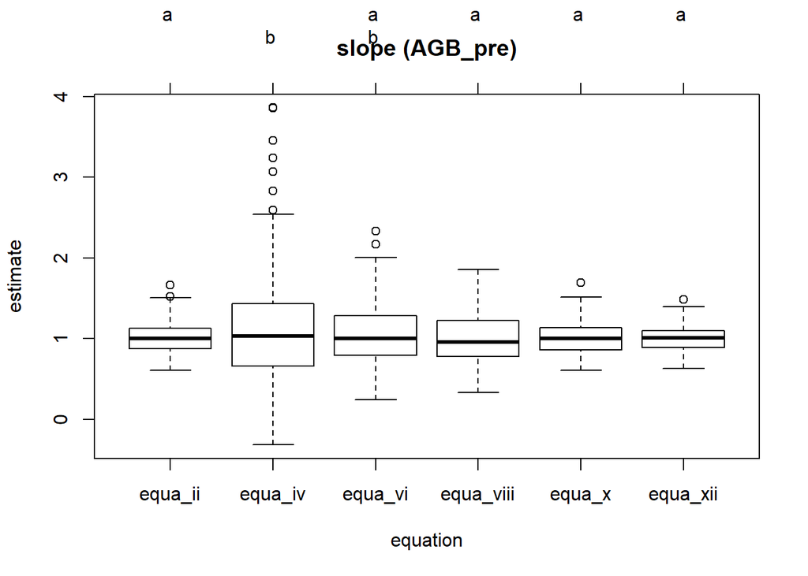

```r
plot(test_term_equation$model.summ[[2]] %>% multcomp::cld(), main = "slope (AGB_pre)")
```